# MTH 209 Data Manipulation and Management

Lesson 14: Creating a Map Using ggplot2

Ying-Ju Tessa Chen  
ychen4@udayton.edu  
University of Dayton

# Overview

In this session, we will talk about how to create a map using the R package ggplot2.

In order to create a map, we will need the following two key functions

- map_data() from the package maps to access the map data related to longitude and latitude.
- geom_polygon() from the package ggplot2 to create a map.

```r
library(pacman)
p_load(tidyverse, maps, viridis)
```

Let’s take a look at the usage of the function map_data().

```
map_data(map, region = ".", exact = FALSE, ...)
```

Arguments:

- map: name of map provided by the package. These include county, france, italy, nz, state, usa, world, world2
- region: name of subregions. “.” means all subregions are included.
- exact: the region is treated as a regular expression (FALSE) or as a fixed string (TRUE).

**Note**: The package viridis provides color maps designed to improve graph readability for readers with common forms of color blindness and/or color vision deficiency.

# A Simple World Map

Let’s create a simple world map.

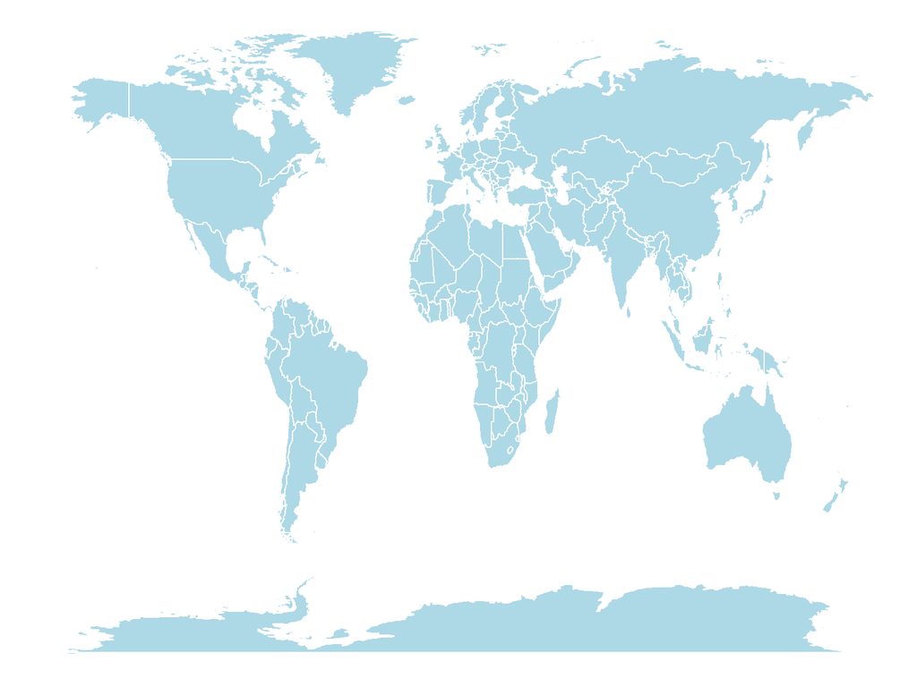

```r
map <- map_data("world")
ggplot(map, aes(x = long, y=lat, group = group)) +
  geom_polygon(fill="lightblue", colour = "white") +
  theme_void()
```